# Assignment_2

2023-10-16

```r
css=read.table("Bankingfull.txt", header=T, sep="\t")
Age=css[,1]
Education=css[,2]
Income=css[,3]
HomeVal=css[,4]
Wealth=css[,5]
Balance=css[,6]
```

```r
summary(css)
```

```
##       Age          Education         Income          HomeVal
##  Min.   :19.50   Min.   :11.00   Min.   :  7741   Min.   : 40313
##  1st Qu.:33.92   1st Qu.:12.40   1st Qu.: 35078   1st Qu.: 83017
##  Median :36.10   Median :12.70   Median : 47656   Median : 97744
##  Mean   :35.45   Mean   :12.98   Mean   : 48811   Mean   :106845
##  3rd Qu.:37.58   3rd Qu.:13.20   3rd Qu.: 60157   3rd Qu.:121791
##  Max.   :43.10   Max.   :16.10   Max.   :111548   Max.   :276139
##      Wealth          Balance
##  Min.   : 24999   Min.   : 5956
##  1st Qu.: 70263   1st Qu.:20036
##  Median :102348   Median :24661
##  Mean   :109026   Mean   :24888
##  3rd Qu.:142518   3rd Qu.:29180
##  Max.   :331009   Max.   :56569
```

#Problem 1

1. Create scatterplots to visualize the associations between bank balance and the other five variables.

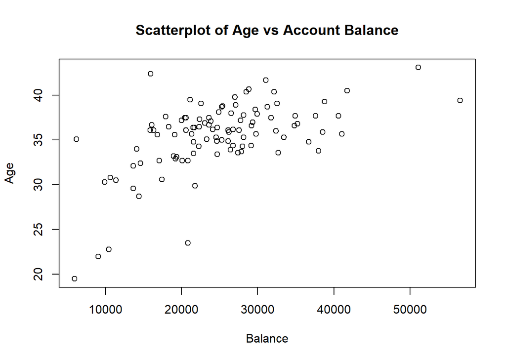

```r
plot(Balance,Age, main="Scatterplot of Age vs Account Balance")
```

From above graph. we can observe that the association between Balance and Age looks fairly linear with few outliers.

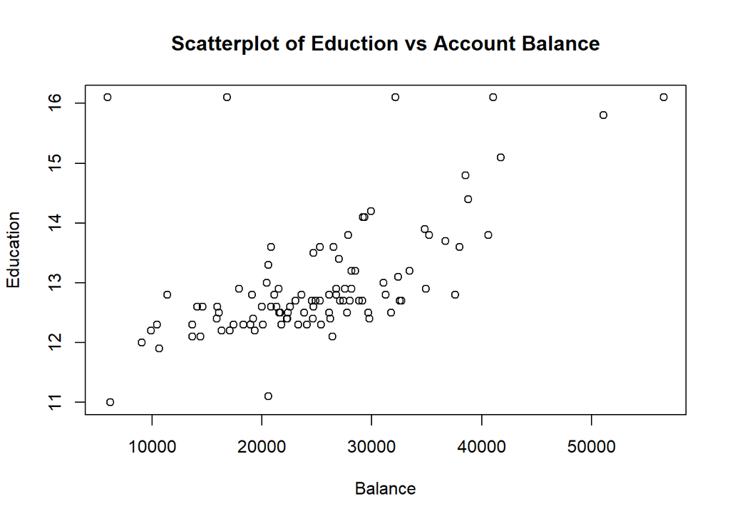

```r
plot(Balance,Education, main="Scatterplot of Eduction vs Account Balance")
```

From above graph. we can observe that the association between Balance and Education looks linear with less amount of outliers.

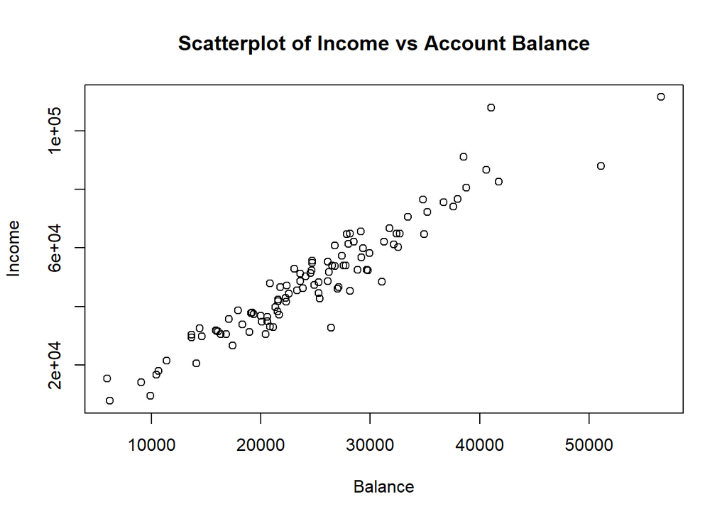

```r
plot(Balance,Income, main="Scatterplot of Income vs Account Balance")
```

From above graph. we can observe that the association between Balance and Income looks linear with few outliers.It seems that both are strongly correlated.

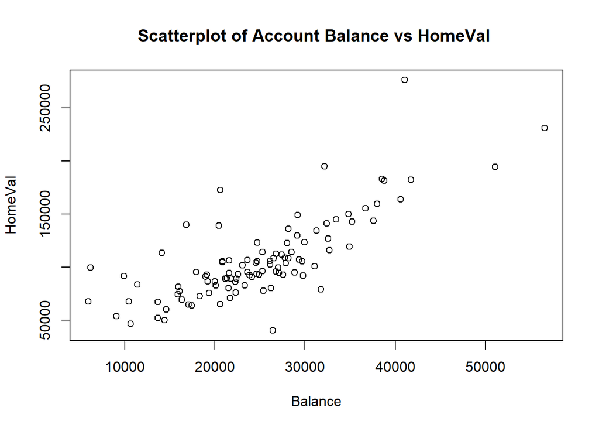

```r
plot(Balance,HomeVal, main="Scatterplot of Account Balance vs HomeVal ")
```

From above graph. we can observe that the association between Balance and HomeVal looks linear with less outliers.

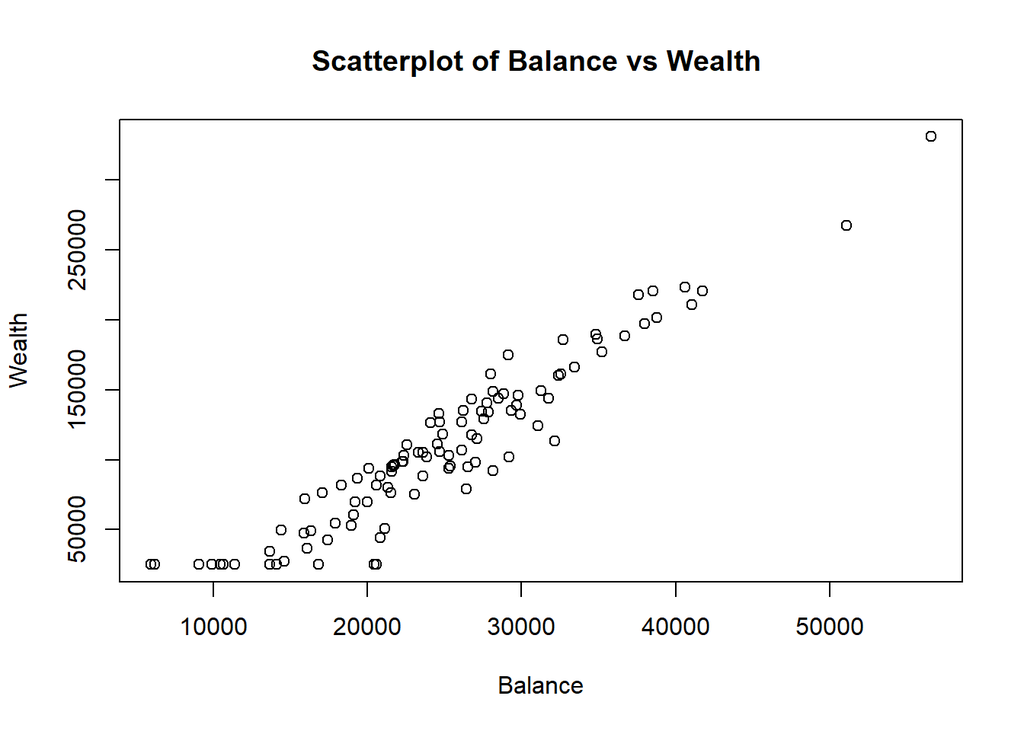

```r
plot(Balance,Wealth, main="Scatterplot of Balance vs Wealth ")
```

From above graph. we can observe that the association between Balance and Wealth looks linear with no outliers.It seems that wealth and Balance are strongly correlated.

2. Compute correlation values of bank balance vs the other variables. Interpret the correlation values, and discuss which variables appear to be strongly associated.

```r
cor(css, method="pearson")
```

```
##                 Age Education    Income   HomeVal    Wealth   Balance
## Age       1.0000000 0.1734071 0.4771474 0.3864931 0.4680918 0.5654668
## Education 0.1734071 1.0000000 0.5753940 0.7535211 0.4694130 0.5548807
## Income    0.4771474 0.5753940 1.0000000 0.7953552 0.9466654 0.9516845
## HomeVal   0.3864931 0.7535211 0.7953552 1.0000000 0.6984778 0.7663871
## Wealth    0.4680918 0.4694130 0.9466654 0.6984778 1.0000000 0.9487117
## Balance   0.5654668 0.5548807 0.9516845 0.7663871 0.9487117 1.0000000
```

Above data shows all the possible correlations. Here we can observe that with account balance, wealth and Income are strongly correlated as (Balance and income) has correlation value of 0.9516845. While, (balance and Wealth) has correlation value of 0.9487117.We can also say (balance and Homeval) are strongly correalted with 0.7663871. Other than that, apart of all the correlations with balance, (wealth and income) with 0.9466654 , (Education and HomeVal) with 0.7535211 are also strongly correlated

3. Fit a regression model of balance vs the other five variables (model M1). Compute the VIF statistics for each x-variable and analyze whether there is a problem of multicollinearity.

```r
fullfit <- lm(Balance ~ Age+Education+Income+HomeVal+Wealth, data=css)
summary(fullfit)
```

```
##
## Call:
## lm(formula = Balance ~ Age + Education + Income + HomeVal + Wealth,
##     data = css)
##
## Residuals:
##     Min      1Q  Median      3Q     Max
## -5376.9 -1110.8   -77.2   872.3  7732.3
##
## Coefficients:
##               Estimate Std. Error t value Pr(>|t|)
## (Intercept) -1.071e+04  4.261e+03  -2.514 0.013613 *
## Age          3.187e+02  6.099e+01   5.225 1.01e-06 ***
## Education    6.219e+02  3.190e+02   1.950 0.054135 .
## Income       1.463e-01  4.078e-02   3.588 0.000527 ***
## HomeVal      9.183e-03  1.104e-02   0.832 0.407505
## Wealth       7.433e-02  1.119e-02   6.643 1.85e-09 ***
## ---
## Signif. codes:  0 '***' 0.001 '**' 0.01 '*' 0.05 '.' 0.1 ' ' 1
##
## Residual standard error: 2056 on 96 degrees of freedom
## Multiple R-squared:  0.9469, Adjusted R-squared:  0.9441
## F-statistic: 342.4 on 5 and 96 DF,  p-value: < 2.2e-16
```

With above fit, Model 1: Balance= (-1.071e+04)+(3.187e+02)Age+(6.219e+02)Education+(1.463e-01)Income+(9.183e-03)HomeVal+(7.433e-02)Wealth+e

VIF Statistics

```r
library(car)
vif(fullfit)
```

```
##       Age Education    Income   HomeVal    Wealth
##  1.342764  2.456706 14.901724  4.382999 10.714276
```

From above tabular data, we observe that there is multicollinearity problem with wealth and income. Wealth and Income is highly co-linear with other variables as covariant >= 10. Wealth has covariant 10.714276 and Income has 14.901724.

4. Apply your knowledge of regression analysis to define a better model M2, and answer the following questions: • Analyze the Coefficient of Determination R2 values and the adjusted adj-R2 values for both models M1 and M2. Which model has the largest adj-R2 value?

Lets first try removing the multicollinearity covariant:

```r
fullfit_2 <- lm(Balance ~ Age+Education+HomeVal, data=css)
summary(fullfit_2)
```

```
##
## Call:
## lm(formula = Balance ~ Age + Education + HomeVal, data = css)
##
## Residuals:
##      Min       1Q   Median       3Q      Max
## -16790.7  -2206.7    607.1   2377.9  12085.1
##
## Coefficients:
##               Estimate Std. Error t value Pr(>|t|)
## (Intercept) -1.933e+04  1.040e+04  -1.858   0.0661 .
## Age          7.194e+02  1.429e+02   5.035 2.17e-06 ***
## Education    3.056e+02  7.750e+02   0.394   0.6942
## HomeVal      1.380e-01  2.144e-02   6.436 4.53e-09 ***
## ---
## Signif. codes:  0 '***' 0.001 '**' 0.01 '*' 0.05 '.' 0.1 ' ' 1
##
## Residual standard error: 5049 on 98 degrees of freedom
## Multiple R-squared:  0.6731, Adjusted R-squared:  0.6631
## F-statistic: 67.26 on 3 and 98 DF,  p-value: < 2.2e-16
```

Here, we observe that the R-squared got lowered down to 0.6731 and adjusted-R2 lowered to 0.6631. Hence, we can say model 1 is better model. Model 2: Balance= (-1.933e+04)+(7.194e+02)Age+(3.056e+02)Education+(1.380e-01)HomeVal+e

Now, lets try removing the non significant values x values.

```r
fullfit_3 <- lm(Balance ~ Age+Income+Wealth+Education, data=css)
summary(fullfit_3)
```

```
##
## Call:
## lm(formula = Balance ~ Age + Income + Wealth + Education, data = css)
##
## Residuals:
##     Min      1Q  Median      3Q     Max
## -5413.6 -1214.2   -62.3   981.7  7439.8
##
## Coefficients:
##               Estimate Std. Error t value Pr(>|t|)
## (Intercept) -1.243e+04  3.719e+03  -3.343  0.00118 **
## Age          3.251e+02  6.040e+01   5.382 5.13e-07 ***
## Income       1.598e-01  3.739e-02   4.272 4.52e-05 ***
## Wealth       7.299e-02  1.105e-02   6.603 2.16e-09 ***
## Education    7.734e+02  2.614e+02   2.958  0.00389 **
## ---
## Signif. codes:  0 '***' 0.001 '**' 0.01 '*' 0.05 '.' 0.1 ' ' 1
##
## Residual standard error: 2052 on 97 degrees of freedom
## Multiple R-squared:  0.9465, Adjusted R-squared:  0.9443
## F-statistic: 429.2 on 4 and 97 DF,  p-value: < 2.2e-16
```

-Create residual plots (standardized residuals vs predicted; standardized residuals vs x-variables; and normal plot of residuals). Analyze the residual plots to check if the regression model assumptions are met by the data.

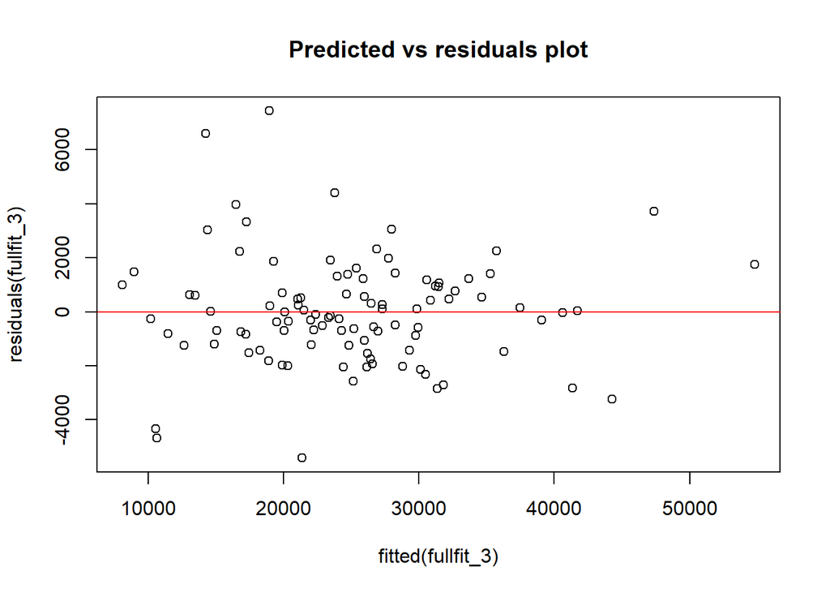

```r
plot( fitted(fullfit_3), residuals(fullfit_3), main="Predicted vs residuals plot")
abline(a=0, b=0, col='red')
```

From above figure we can say points are randomly scattred around the zero line.

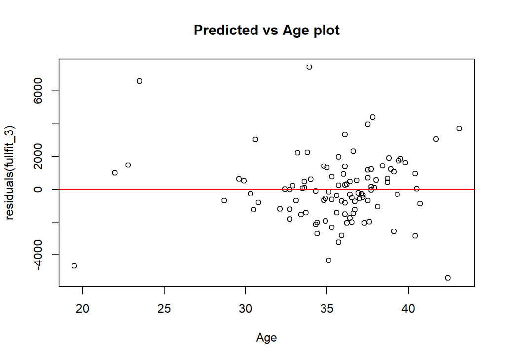

```r
plot( Age, residuals(fullfit_3), main="Predicted vs Age plot")
abline(a=0, b=0, col='red')
```

Here we observe that,most of the data is on right side.

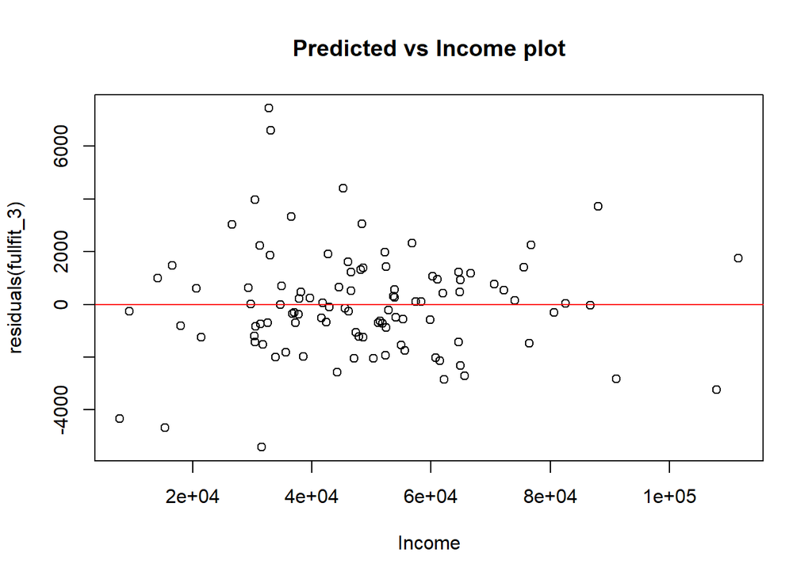

```r
plot( Income, residuals(fullfit_3), main="Predicted vs Income plot")
abline(a=0, b=0, col='red')
```

From above figure we can say points are randomly scattred around the zero line.

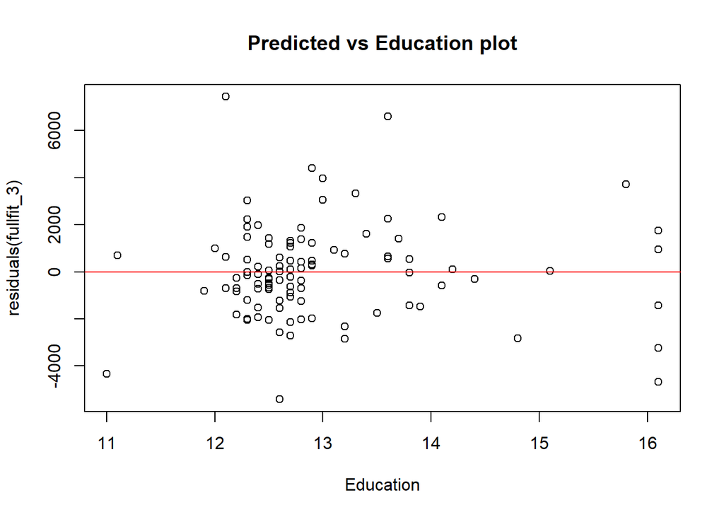

```r
plot( Education, residuals(fullfit_3), main="Predicted vs Education plot")
abline(a=0, b=0, col='red')
```

From above figure we can say points are randomly scattered around the zero line.

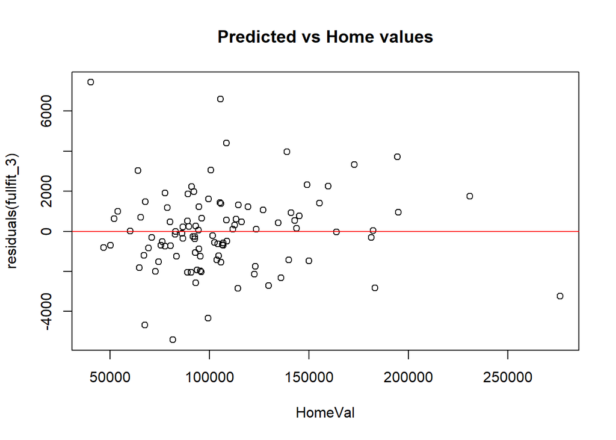

```r
plot( HomeVal, residuals(fullfit_3), main="Predicted vs Home values")
abline(a=0, b=0, col='red')
```

From above figure we can say points are randomly scatter around the zero line.

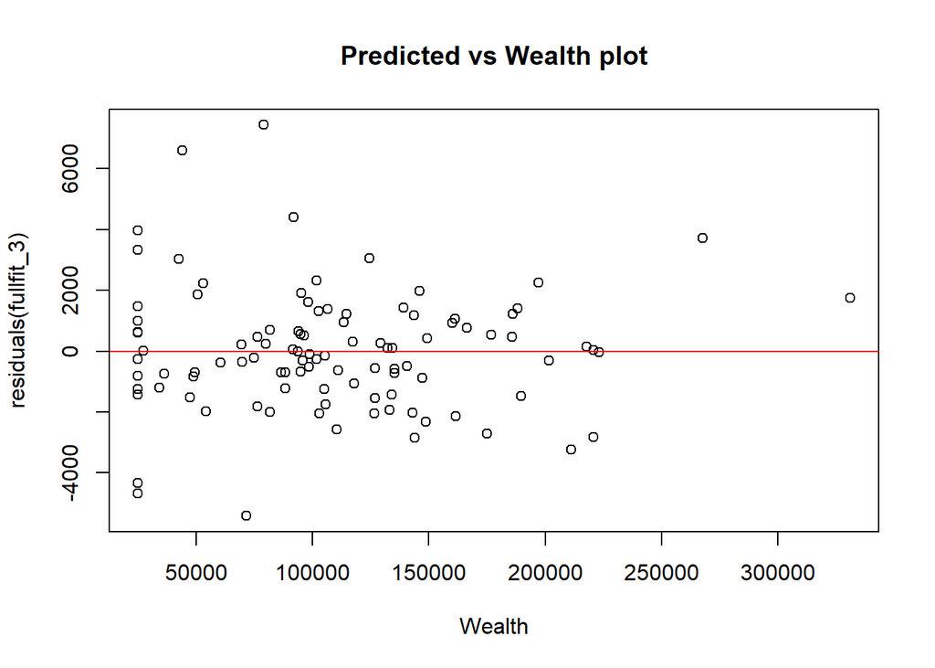

```r
plot( Wealth, residuals(fullfit_3), main="Predicted vs Wealth plot")
abline(a=0, b=0, col='red')
```

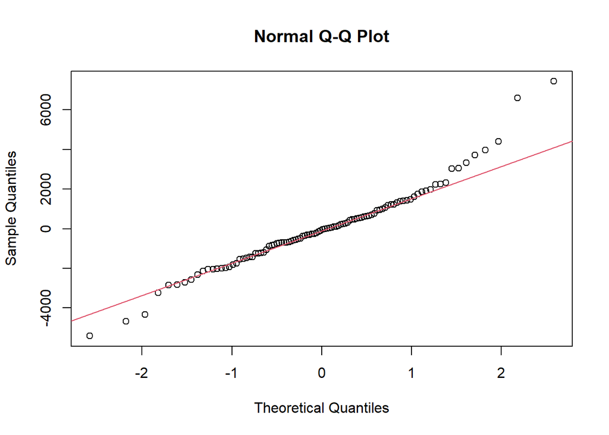

```r
qqnorm(residuals(fullfit_3))
qqline(residuals(fullfit_3), col = 2)
```

The above graph is normal plot of residuals gives us fairly linear graph so our normality assumptions are satisfied.

-Analyze if there are any outliers and influential points for your model. If so, what are your recommendations? Lets find outliers i.e influential points.

```r
influence.measures(fullfit_3)
```

```
## Influence measures of
##   lm(formula = Balance ~ Age + Income + Wealth + Education, data = css) :
##
##        dfb.1_   dfb.Age  dfb.Incm  dfb.Wlth  dfb.Edct    dffit cov.r   cook.d
## 1    0.019109  1.42e-01 -1.55e-01  6.22e-02 -5.83e-02 -0.40083 1.021 3.18e-02
## 2   -0.000406  5.33e-04 -7.50e-04 -7.29e-05  4.70e-04 -0.00261 1.110 1.38e-06
## 3   -0.002025 -6.66e-03  9.44e-03  3.05e-04  2.85e-03  0.04325 1.076 3.78e-04
## 4    0.031069 -2.78e-02  3.89e-02 -1.92e-02 -2.84e-02  0.06965 1.081 9.79e-04
## 5   -0.066169  6.18e-02 -9.60e-02  5.45e-02  5.89e-02 -0.17488 1.007 6.10e-03
## 6    0.037267 -6.86e-02  3.92e-02  2.73e-03 -1.53e-02  0.13932 1.067 3.90e-03
## 7    0.013059 -5.01e-03 -2.52e-03 -2.32e-03 -9.91e-03 -0.03234 1.097 2.11e-04
## 8   -0.002329  3.16e-02 -3.24e-02 -1.68e-03 -3.81e-03 -0.13239 1.058 3.52e-03
## 9    0.087426  2.79e-01 -8.23e-01  7.11e-01 -9.48e-02 -1.08991 1.188 2.32e-01
## 10  -0.002662  1.05e-03 -1.36e-03  1.62e-03  2.50e-03  0.00408 1.139 3.36e-06
## 11  -0.006462  3.12e-03 -1.44e-03  4.68e-04  6.03e-03  0.00865 1.084 1.51e-05
```

[output cut: 194 more lines]

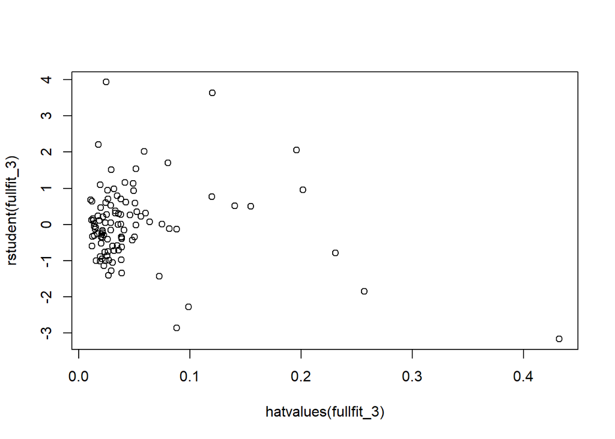

```r
plot(rstudent(fullfit_3)~hatvalues(fullfit_3))
```

```r
summary(influence.measures(fullfit_3))
```

```
## Potentially influential observations of
##   lm(formula = Balance ~ Age + Income + Wealth + Education, data = css) :
##
##     dfb.1_ dfb.Age dfb.Incm dfb.Wlth dfb.Edct dffit   cov.r   cook.d  hat
## 9    0.09   0.28   -0.82     0.71    -0.09    -1.09_*  1.19_*  0.23    0.26_*
## 12  -0.68   0.31   -0.64     0.67     0.67     1.01_*  1.06    0.20    0.20_*
## 15  -0.19   0.09   -0.01    -0.04     0.17     0.21    1.23_*  0.01    0.15_*
## 21  -0.17  -0.05   -0.18     0.27     0.22     0.48    1.26_*  0.05    0.20_*
## 38   0.38  -1.11_*  0.22    -0.22     0.27     1.34_*  0.63_*  0.32    0.12
## 52  -0.08   0.18    0.03    -0.08     0.01     0.30    0.84_*  0.02    0.02
## 59   0.35  -0.11    0.10     0.03    -0.39    -0.43    1.33_*  0.04    0.23_*
## 84   0.48  -0.76    0.42    -0.21    -0.21    -0.89_*  0.77_*  0.15    0.09
## 85   0.82   1.30_*  1.27_*  -0.96    -2.09_*  -2.76_*  1.13    1.40_*  0.43_*
## 91   0.20  -0.04   -0.33     0.31    -0.10     0.63    0.51_*  0.07    0.02
## 98   0.13  -0.23   -0.05     0.06     0.01     0.28    1.16_*  0.02    0.12
## 100  0.11  -0.17   -0.05     0.06     0.00     0.21    1.21_*  0.01    0.14
## 102 -0.07  -0.21    0.50    -0.40     0.07    -0.75_*  0.90    0.11    0.10
```

Here, I observe that there are few outliers and influential points. My recommendation is that Examine each influential point individually and Remove an influential point and see if the model results change, or investigate if influential point is an error or typo.

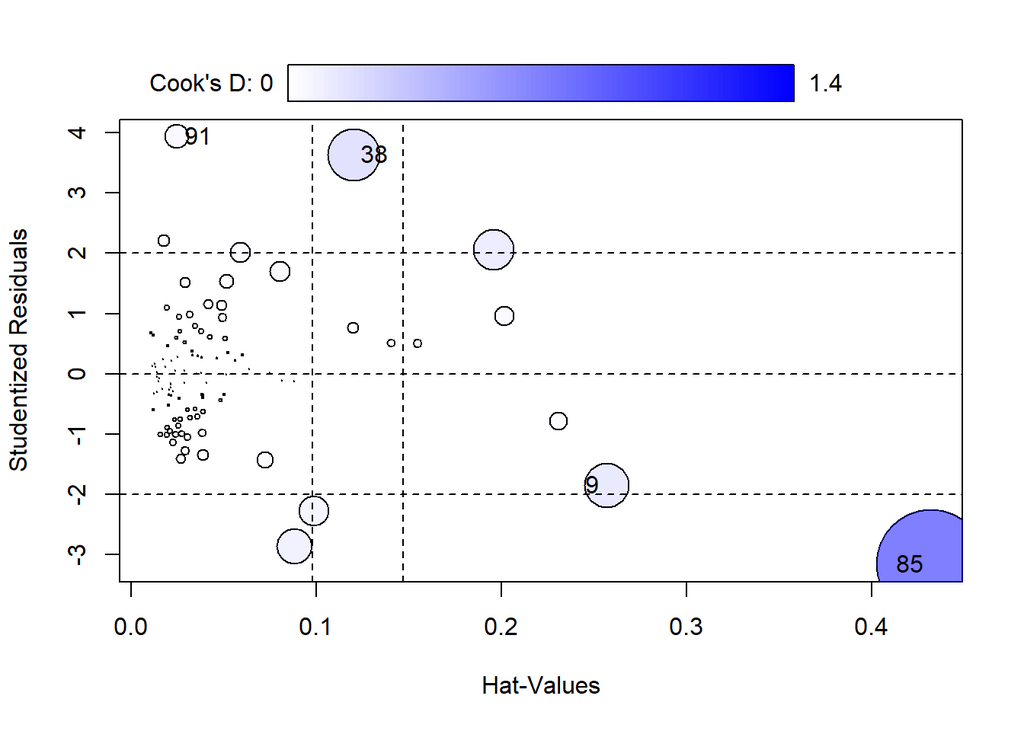

```
##      StudRes        Hat      CookD
## 9  -1.854534 0.25672326 0.23175433
## 38  3.635668 0.12017937 0.32070913
## 85 -3.167461 0.43209105 1.39662726
## 91  3.935608 0.02492385 0.06889218
```

```r
influencePlot(fullfit_3)
```

Observation 38 and 91 stands out as having a relatively high Studentized Residual (3.635668)and 3.935608 respectively, indicating a potential outlier. Also, 85 has cooks greater than 1which is 1.39662726 which shows potential outliers.

-Compute the standardized coefficients and discuss which predictor has the strongest influence on balance?

```r
library(QuantPsyc)
lm.beta(fullfit_3)
```

```
##        Age     Income     Wealth  Education
## 0.14525017 0.35560774 0.50212645 0.08937397
```

According to above data, we can say that wealth has highest influence on balance.

5. Use the fitted regression model from d) without removal of influential points to predict the average bank balance for a specific zip code area where there is a plan to open a new branch. Census data in that area show the following values: median age is 34 years, median education is 13 years, median income is $64,000, median home value is $140,000, median wealth is 160,000. (Note that you may not need all these values in your model). Provide predicted average bank balance and 95% confidence interval for your estimate.

```r
new=data.frame(Age=c(34),Education=c(13),Income=(64000),HomeVal=c(140000),Wealth=c(160000))
predict(fullfit_3, new, interval="prediction", level=0.95)
```

```
##        fit     lwr      upr
## 1 30575.74 26446.1 34705.38
```

# Problem 2

```r
css_1=read.table("pgatour2006_small.csv", header=T, sep=",")
Name=css_1[,1]
PrizeMoney=css_1[,2]
DrivingAccuracy=css_1[,3]
GIR=css_1[,4]
PuttingAverage=css_1[,5]
BirdieConversion=css_1[,6]
PuttsPerRound=css_1[,7]
```

1. Create scatterplots to visualize the associations between PrizeMoney and the other five variables. Discuss the patterns displayed by the scatterplot. Do the associations appear to be linear?

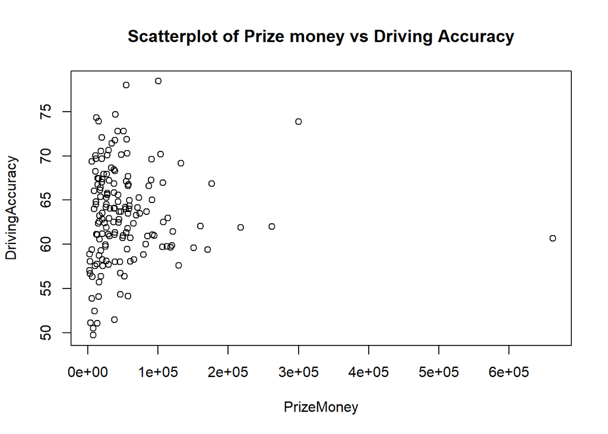

```r
plot(PrizeMoney,DrivingAccuracy, main="Scatterplot of Prize money vs Driving Accuracy")
```

From above plot, we can observe that association between Prize money and Driving Accuracy the data is not linearly associated.

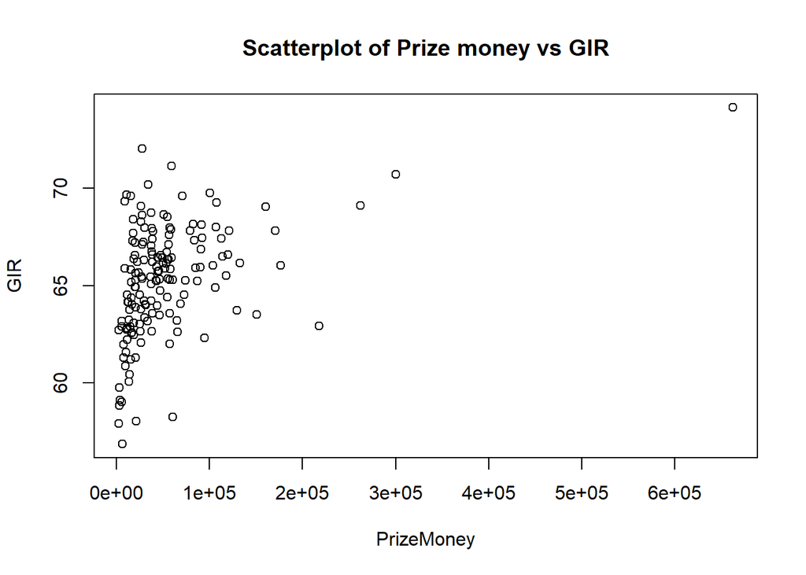

```r
plot(PrizeMoney,GIR, main="Scatterplot of Prize money vs GIR")
```

From above plot, we can observe that association between Prize money and GIR the data is not linearly associated.

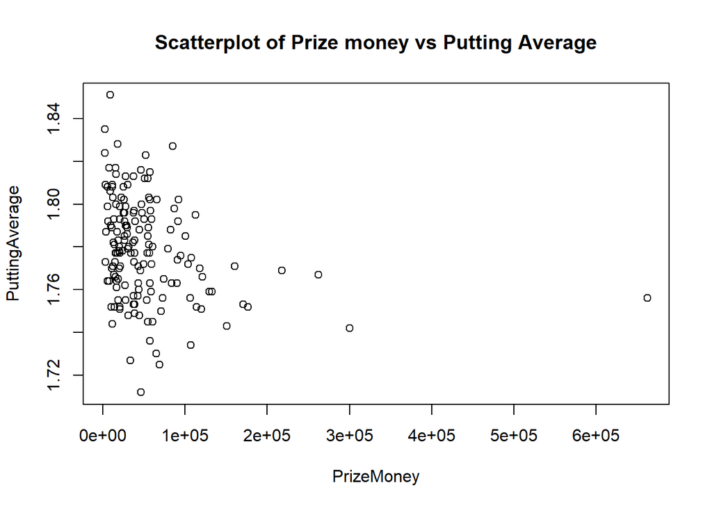

```r
plot(PrizeMoney,PuttingAverage, main="Scatterplot of Prize money vs Putting Average")
```

From above plot, we can observe that association between Prize money and Putting Average the data is not linearly associated.

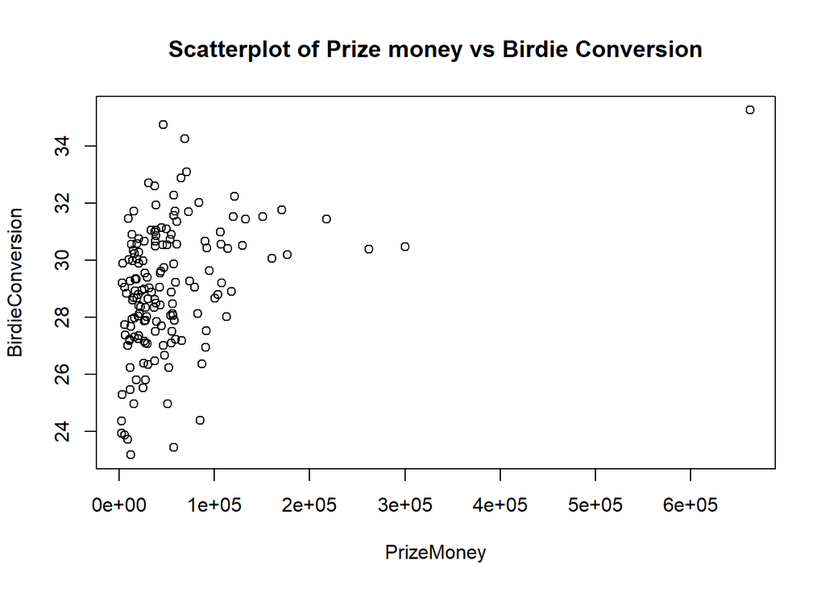

```r
plot(PrizeMoney,BirdieConversion, main="Scatterplot of Prize money vs Birdie Conversion")
```

From above plot, we can observe that association between Prize money and Birdie conversion the data is not linearly associated.

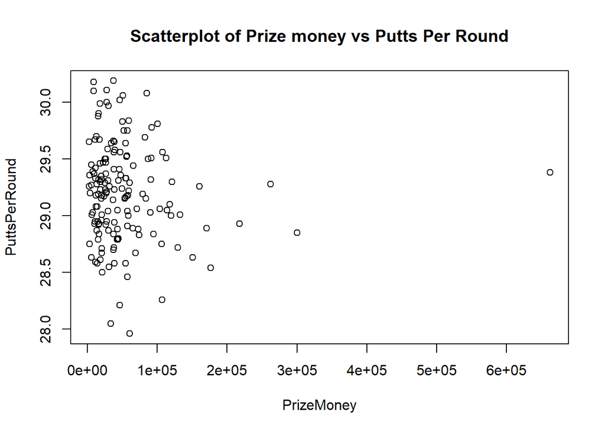

```r
plot(PrizeMoney,PuttsPerRound, main="Scatterplot of Prize money vs Putts Per Round")
```

From above plot, we can observe that association between Prize money and PuttsPerRound the data is not linearly associated.

So we can say that, the association of Price Money with other five variables is not linear.

2. Analyze distribution of PrizeMoney, and discuss if the distribution is symmetric or skewed.

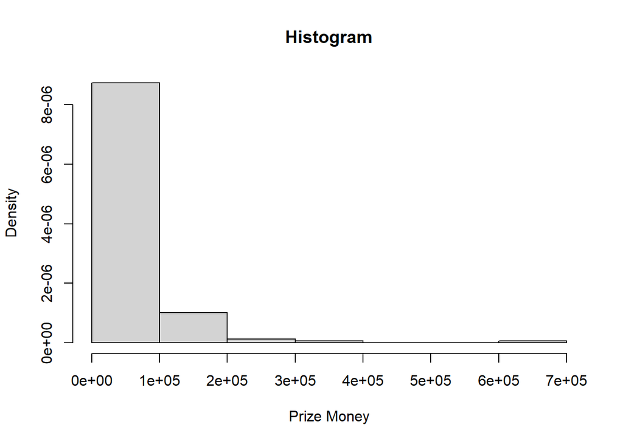

```r
hist(PrizeMoney, xlab="Prize Money", prob=TRUE, main="Histogram")
library(psych)
```

```r
describe(PrizeMoney)
```

```
##    vars   n     mean       sd median  trimmed      mad  min    max  range skew
## X1    1 157 53059.76 67738.72  37214 41686.57 30077.51 2240 662771 660531 5.34
##    kurtosis      se
## X1    41.05 5406.14
```

Here from the figure we observe that, most of the data is in the left side of the graph so we can say that distribution is right skewed. Other than that here, mean is greater than median which also supports that data distribution is right skewed.

3. Apply a log transformation to PrizeMoney and compute the new variable ln_Prize=log(PrizeMoney). Analyze distribution of ln_Prize, and discuss if the distribution is symmetric or skewed.

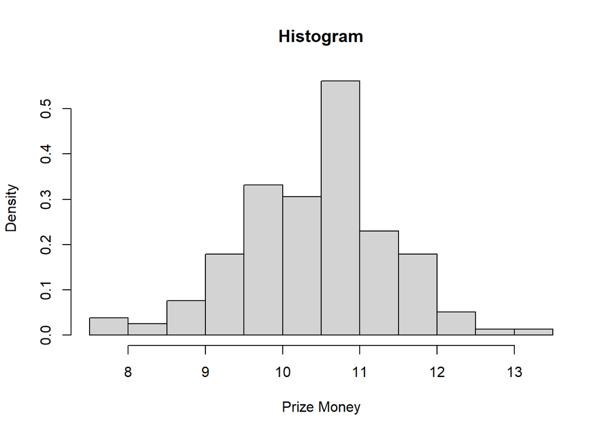

```r
hist(log(PrizeMoney), xlab="Prize Money", prob=TRUE, main="Histogram")
```

```r
library(psych)
describe(log(PrizeMoney))
```

```
##    vars   n  mean   sd median trimmed  mad  min  max range  skew kurtosis   se
## X1    1 157 10.43 0.97  10.52   10.45 0.92 7.71 13.4  5.69 -0.24      0.4 0.08
```

After applying log transformation, we can see that the data distribution is approximately symmetric and normal.While here, mean and median are nearly same which supports that the distribution is symmetric.

4. Fit a regression model of ln_Prize using the remaining predictors in your dataset. Apply your knowledge of regression analysis to define a valid model to predict ln_Prize. Hint: use scatter plots and correlation

```r
coln<-css_1[,2:7]
cor(coln,method='pearson')
```

```
##                   PrizeMoney DrivingAccuracy          GIR PuttingAverage
## PrizeMoney        1.00000000     0.049543172  0.422367098   -0.268926938
## DrivingAccuracy   0.04954317     1.000000000  0.429569950   -0.009947186
## GIR               0.42236710     0.429569950  1.000000000    0.086771184
## PuttingAverage   -0.26892694    -0.009947186  0.086771184    1.000000000
## BirdieConversion  0.37422230    -0.267821730 -0.004445415   -0.775514425
## PuttsPerRound    -0.06643276     0.081490975  0.506009428    0.788477408
##                  BirdieConversion PuttsPerRound
## PrizeMoney            0.374222299   -0.06643276
## DrivingAccuracy      -0.267821730    0.08149097
## GIR                  -0.004445415    0.50600943
## PuttingAverage       -0.775514425    0.78847741
## BirdieConversion      1.000000000   -0.49560641
## PuttsPerRound        -0.495606408    1.00000000
```

```r
fullpga <- lm(log(PrizeMoney) ~ DrivingAccuracy+GIR+PuttingAverage+BirdieConversion+PuttsPerRound, data=css_1)
summary(fullpga)
```

```
##
## Call:
## lm(formula = log(PrizeMoney) ~ DrivingAccuracy + GIR + PuttingAverage +
##     BirdieConversion + PuttsPerRound, data = css_1)
##
## Residuals:
##      Min       1Q   Median       3Q      Max
## -1.58988 -0.52262 -0.09792  0.45839  1.99841
##
## Coefficients:
##                   Estimate Std. Error t value Pr(>|t|)
## (Intercept)       0.466245   8.568501   0.054 0.956677
## DrivingAccuracy   0.004063   0.013239   0.307 0.759351
## GIR               0.257773   0.030923   8.336  4.4e-14 ***
## PuttingAverage   11.745503   6.480301   1.812 0.071897 .
## BirdieConversion  0.175061   0.047399   3.693 0.000309 ***
## PuttsPerRound    -1.133206   0.312031  -3.632 0.000385 ***
## ---
## Signif. codes:  0 '***' 0.001 '**' 0.01 '*' 0.05 '.' 0.1 ' ' 1
##
## Residual standard error: 0.6806 on 151 degrees of freedom
## Multiple R-squared:  0.5264, Adjusted R-squared:  0.5108
## F-statistic: 33.57 on 5 and 151 DF,  p-value: < 2.2e-16
```

Above is a model design including all variables. Model_1: log(PrizeMoney)=0.466245+(0.004063)DrivingAccuracy+(0.257773)GIR+(11.745503)PuttingAverage+(0.175061)BirdieConversion-(1.133206)PuttsPerRound+e Here,we got R-squared: 0.5264, Adjusted R-squared: 0.5108

```r
vif(fullpga)
```

```
##  DrivingAccuracy              GIR   PuttingAverage BirdieConversion
##         1.741000         2.676394         8.089367         3.745871
##    PuttsPerRound
##         6.104434
```

Here we can see all are <10 so there is no multicollinearity problem.

-If necessary remove not significant variables. Remember to remove one variable at a time (variable with largest p-value is removed first) and refit the model, until all variables are significant.

Lets remove non significant variables

```r
newfullpga <- lm(log(PrizeMoney) ~ GIR+BirdieConversion+PuttsPerRound, data=css_1)
summary(newfullpga)
```

```
##
## Call:
## lm(formula = log(PrizeMoney) ~ GIR + BirdieConversion + PuttsPerRound,
##     data = css_1)
##
## Residuals:
##      Min       1Q   Median       3Q      Max
## -1.66871 -0.51948 -0.09127  0.47568  1.93933
##
## Coefficients:
##                  Estimate Std. Error t value Pr(>|t|)
## (Intercept)      11.78325    5.05724   2.330 0.021114 *
## GIR               0.23571    0.02330  10.115  < 2e-16 ***
## BirdieConversion  0.11702    0.02998   3.903 0.000142 ***
## PuttsPerRound    -0.68946    0.17926  -3.846 0.000176 ***
## ---
## Signif. codes:  0 '***' 0.001 '**' 0.01 '*' 0.05 '.' 0.1 ' ' 1
##
## Residual standard error: 0.6835 on 153 degrees of freedom
## Multiple R-squared:  0.5161, Adjusted R-squared:  0.5066
## F-statistic:  54.4 on 3 and 153 DF,  p-value: < 2.2e-16
```

Here we removed the non-significant variables and refit the model and the model we got is: log(PrizeMoney)=11.78325+0.23571 (GIR)+0.11702 (BirdieConversion)-0.68946(PuttsPerRound )+e

Analyze residual plots to check if the regression model is valid for your data.

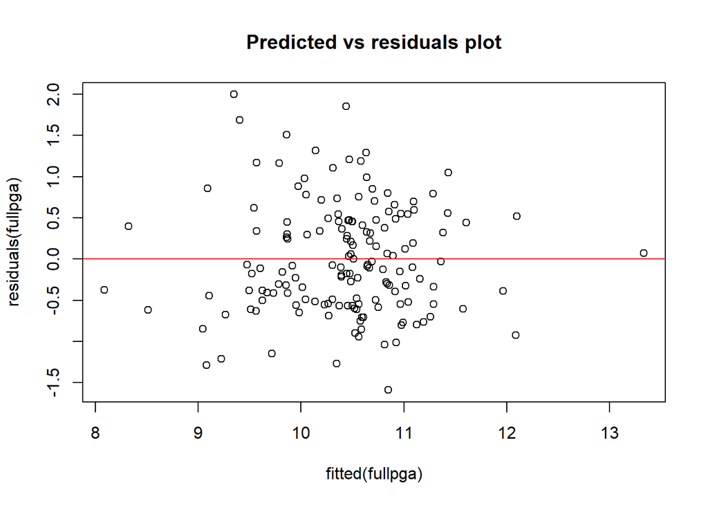

```r
plot( fitted(fullpga), residuals(fullpga), main="Predicted vs residuals plot")
abline(a=0, b=0, col='red')
```

The graph describes that, data is randomly scattered.

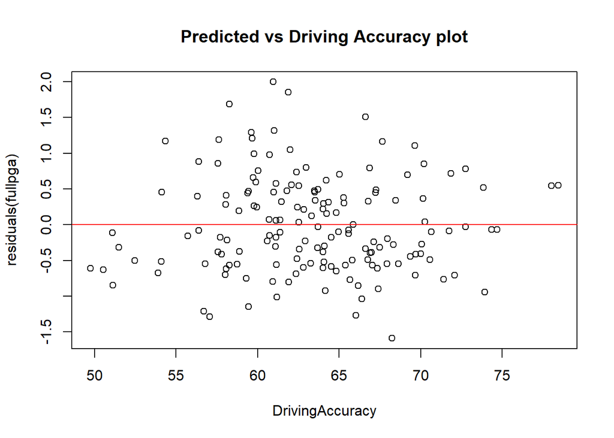

```r
plot( DrivingAccuracy, residuals(fullpga), main="Predicted vs Driving Accuracy plot")
abline(a=0, b=0, col='red')
```

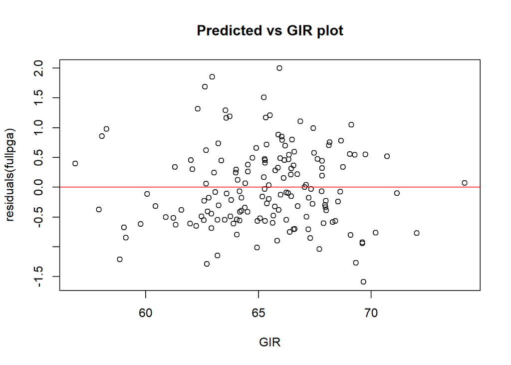

```r
plot( GIR, residuals(fullpga), main="Predicted vs GIR plot")
abline(a=0, b=0, col='red')
```

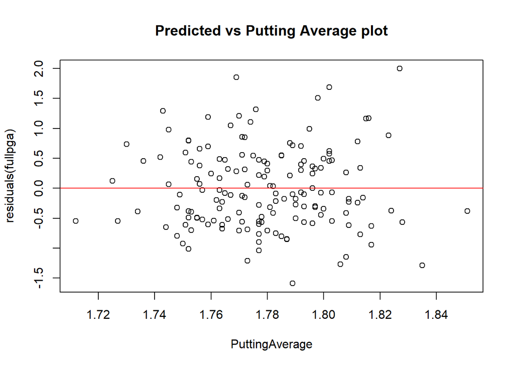

```r
plot( PuttingAverage, residuals(fullpga), main="Predicted vs Putting Average plot")
abline(a=0, b=0, col='red')
```

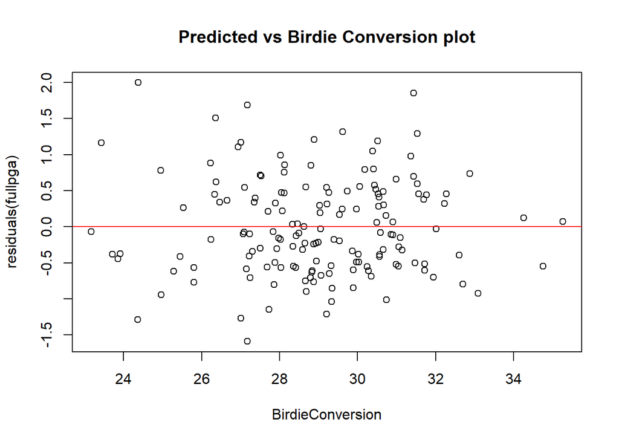

```r
plot( BirdieConversion, residuals(fullpga), main="Predicted vs Birdie Conversion plot")
abline(a=0, b=0, col='red')
```

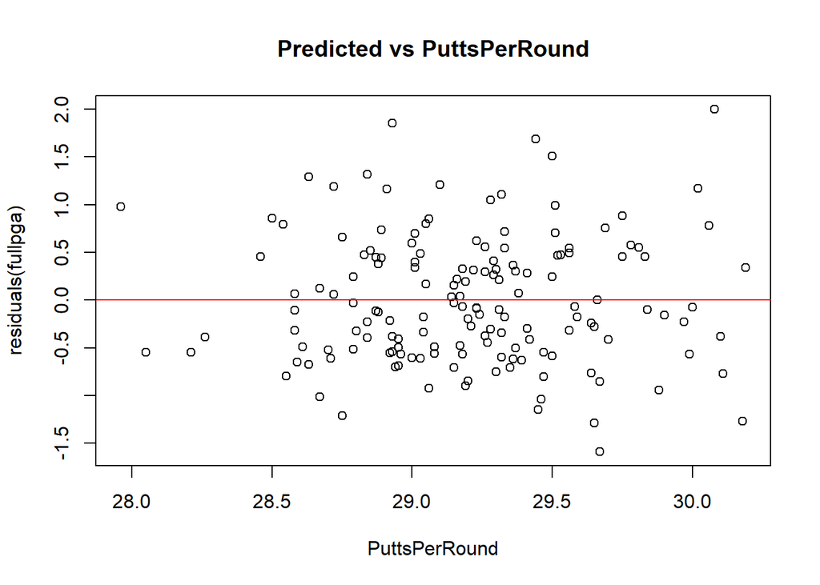

```r
plot( PuttsPerRound, residuals(fullpga), main="Predicted vs PuttsPerRound")
abline(a=0, b=0, col='red')
```

From the residual vs fitted and the residuals vs all the x-values we observe that the distribution is random and scattered.

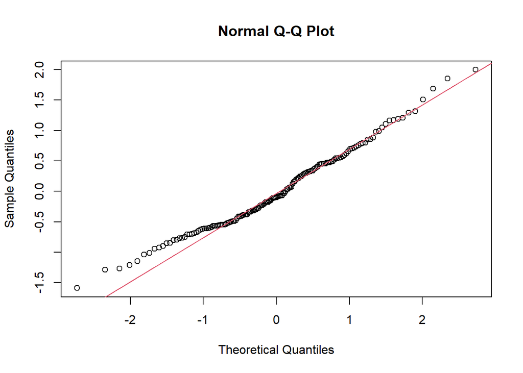

```r
qqnorm(residuals(fullpga))
qqline(residuals(fullpga), col = 2)
```

Hence, random distribution gives us fairly linear points in plot . Hence assumption of normality satisfied.

-Analyze if there are any outliers and influential points. If there are points in the dataset that need to be investigated, give one or more reason to support each point chosen.

```r
influence.measures(fullpga)
```

[output not shown]

[output cut: 304 more lines]

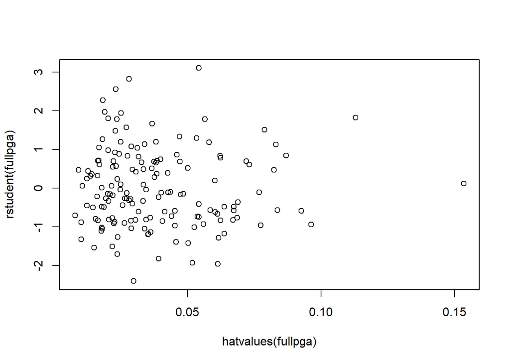

```r
plot(rstudent(fullpga)~hatvalues(fullpga))
```

```r
summary(influence.measures(fullpga))
```

```
## Potentially influential observations of
##   lm(formula = log(PrizeMoney) ~ DrivingAccuracy + GIR + PuttingAverage +      BirdieConversion + PuttsPerRound, data = css_1) :
##
##     dfb.1_ dfb.DrvA dfb.GIR dfb.PttA dfb.BrdC dfb.PtPR dffit   cov.r   cook.d
## 9    0.04   0.06    -0.09   -0.09    -0.13     0.11     0.31    0.87_*  0.02
## 40   0.04  -0.02     0.27    0.33    -0.14    -0.48     0.65_*  1.03    0.07
## 47  -0.10   0.04    -0.14    0.16     0.20    -0.10    -0.42    0.85_*  0.03
## 63  -0.26   0.20    -0.17    0.21     0.37    -0.06     0.48    0.79_*  0.04
## 70  -0.01   0.01     0.07   -0.01     0.04     0.00    -0.17    1.12_*  0.00
## 113 -0.01  -0.01     0.00    0.00     0.02     0.00    -0.03    1.13_*  0.00
## 120 -0.10   0.10    -0.09    0.05     0.11     0.03     0.14    1.12_*  0.00
## 133 -0.08   0.04    -0.14   -0.03     0.04     0.13    -0.19    1.13_*  0.01
## 139 -0.02  -0.01     0.03    0.02     0.03    -0.02     0.05    1.23_*  0.00
## 141  0.01  -0.12    -0.15   -0.05    -0.10     0.11     0.39    0.82_*  0.02
## 146  0.10  -0.25    -0.08   -0.24    -0.40     0.31     0.74_*  0.76_*  0.09
##     hat
## 9    0.02
## 40   0.11
## 47   0.03
## 63   0.03
## 70   0.08
## 113  0.08
## 120  0.08
## 133  0.09
## 139  0.15_*
## 141  0.02
## 146  0.05
```

Observing above graph we can say there is only one outlier.Influential points can have a significant impact on the regression model’s parameters and predictions. These points may be outliers in the dataset, having extreme values for some predictors.They may represent cases that deviate from the overall pattern observed in the data. I choose one point as an outlier as it was High Deleted Studentized Residuals (outside (-3,3) band).Other than that if the point has High leverage hat hii value (> 0.5) or High Cook’s D distance (>1) than that is considered as outlier or influential point.

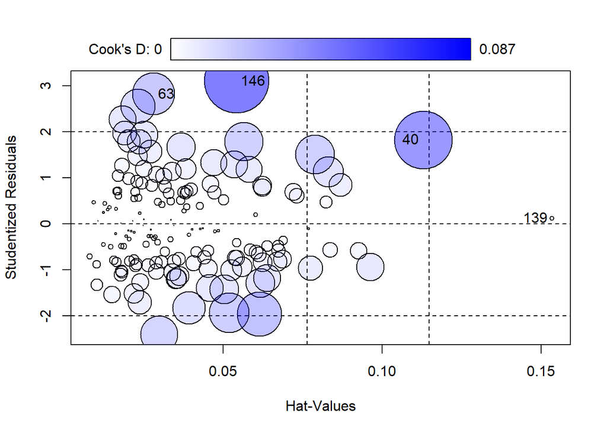

```
##       StudRes        Hat        CookD
## 40  1.8266511 0.11280443 0.0696302134
## 63  2.8218204 0.02812880 0.0367174478
## 139 0.1165732 0.15333455 0.0004128772
## 146 3.1043734 0.05417722 0.0870255193
```

```r
influencePlot(fullpga)
```

5. Interpret the regression coefficients in the final model to answer the following question: How does an increase in 1% for GIR affect the average Prize money?

```r
coef(fullpga)["GIR"]
```

```
##       GIR
## 0.2577731
```

```r
exp(coef(fullpga)["GIR"])
```

```
##      GIR
## 1.294045
```

6. Compute the prediction and 95% prediction interval for average prize money for a player that has a GIR of 67%, driving accuracy of 64%, putting average of 1.77, Birdie Conversion of 28% and 29.16 average putts per round.

```r
new=data.frame(DrivingAccuracy=c(64),GIR=c(67),BirdieConversion=c(28),PuttingAverage=c(1.77),PuttsPerRound=c(29.16))
predict(fullpga, new, interval="prediction", level=0.95)
```

```
##        fit      lwr      upr
## 1 10.64403 9.281873 12.00618
```

```r
exp(predict(fullpga, new, interval="prediction", level=0.95) )
```

```
##        fit      lwr      upr
## 1 41941.37 10741.53 163764.2
```

This model prediction for a player that has a GIR of 67%, driving accuracy of 64%, putting average of 1.77, Birdie Conversion of 28% and 29.16 average putts per round gives 95% prediction interval (10741.53,163764.2) and average Price money 41941.37.